# MedicalCost

### Problem Statement

Healthcare **costs are rising globally**, with individual medical insurance charges often varying widely due to factors like age, BMI, smoking status, and more. This unpredictability poses a challenge for insurance providers to accurately assess risk and set fair premiums. Inconsistent pricing can lead to undercharging high-risk individuals or overcharging low-risk ones, affecting both profitability and fairness. By analyzing historical insurance data and building *predictive models*, we can **identify key cost drivers and forecast charges** more accurately, leading to data-driven pricing, better resource planning, and improved customer satisfaction.

```python
import pandas as pd
import matplotlib.pyplot as plt
import seaborn as sns
import numpy as np
from scipy import stats
```

```python
sns.set_theme(rc ={'axes.axisbelow': True},
    style= {"axes.facecolor":"#F4F1E1",
                      'axes.edgecolor': '#603F26',
                      'patch.edgecolor':"#AD8B73",'patch.force_edgecolor': True,
                      "grid.color":"#D1C6A1", "axes.grid":True})
sns.set_palette([
    '#AD8B73',  # earthy beige-brown
    '#CEAB93',  # soft tan
    '#E3CAA5',  # warm light cream
    '#FFEAC5',  # Light cream
    '#FFDBB5',  # Soft peach
    '#6C4E31',  # Rich brown
    '#603F26'   # Deep brown
])


np.set_printoptions(suppress=True)
```

```python
df = pd.read_csv("data/insurance.csv")
```

## Overview of dataset

```python
df.info() # 4 numerical values and 3 objects
```

```
<class 'pandas.core.frame.DataFrame'>
RangeIndex: 1338 entries, 0 to 1337
Data columns (total 7 columns):
 #   Column    Non-Null Count  Dtype
---  ------    --------------  -----
 0   age       1338 non-null   int64
 1   sex       1338 non-null   object
 2   bmi       1338 non-null   float64
 3   children  1338 non-null   int64
 4   smoker    1338 non-null   object
 5   region    1338 non-null   object
 6   charges   1338 non-null   float64
dtypes: float64(2), int64(2), object(3)
memory usage: 73.3+ KB
```

```python
df.isna().sum()
```

```
age         0
sex         0
bmi         0
children    0
smoker      0
region      0
charges     0
dtype: int64
```

```python
df_numerical = df.describe().columns
df_categorical = df.describe(include="object").columns
```

#### Numerical Features

```python
df.describe() # for numerical value
```

|  | age | bmi | children | charges |
| --- | --- | --- | --- | --- |
| count | 1338.000000 | 1338.000000 | 1338.000000 | 1338.000000 |
| mean | 39.207025 | 30.663397 | 1.094918 | 13270.422265 |
| std | 14.049960 | 6.098187 | 1.205493 | 12110.011237 |
| min | 18.000000 | 15.960000 | 0.000000 | 1121.873900 |
| 25% | 27.000000 | 26.296250 | 0.000000 | 4740.287150 |
| 50% | 39.000000 | 30.400000 | 1.000000 | 9382.033000 |
| 75% | 51.000000 | 34.693750 | 2.000000 | 16639.912515 |
| max | 64.000000 | 53.130000 | 5.000000 | 63770.428010 |

```python
df.skew(numeric_only=True)  #skewness of numerical values
```

```
age         0.055673
bmi         0.284047
children    0.938380
charges     1.515880
dtype: float64
```

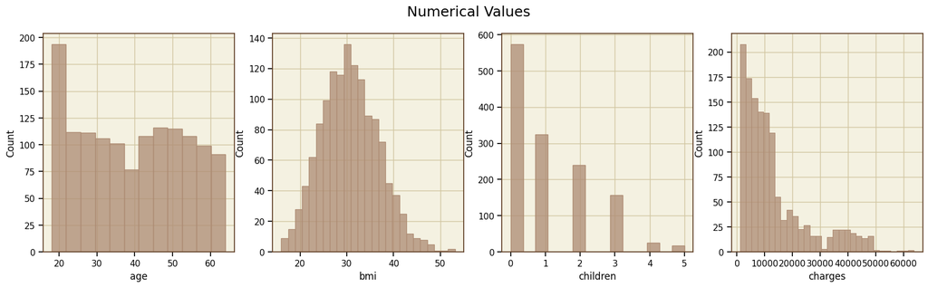

```python
fig, axs = plt.subplots(ncols = len(df_numerical), figsize=(20, 5))
for i, col in enumerate(df_numerical):
    sns.histplot(df, x = col, ax = axs[i])

plt.suptitle("Numerical Values", fontsize = 18)
```

#### Categorical Features

```python
df.describe(include="object") # for categorical values
```

|  | sex | smoker | region |
| --- | --- | --- | --- |
| count | 1338 | 1338 | 1338 |
| unique | 2 | 2 | 4 |
| top | male | no | southeast |
| freq | 676 | 1064 | 364 |

```python
for i in df_categorical:
    print(f"{df[i].value_counts()}\n")
```

```
sex
male      676
female    662
Name: count, dtype: int64

smoker
no     1064
yes     274
Name: count, dtype: int64

region
southeast    364
southwest    325
northwest    325
northeast    324
Name: count, dtype: int64
```

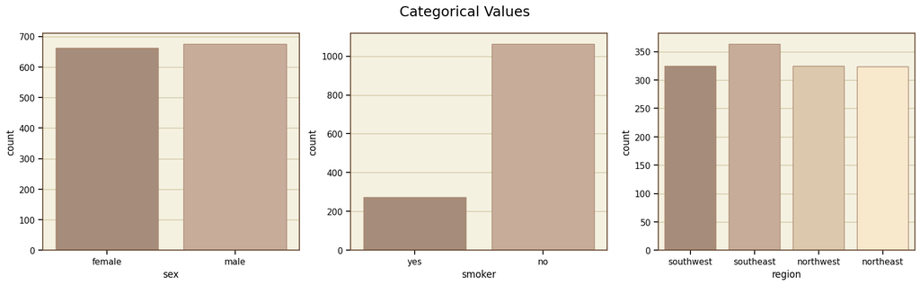

```python
fig, axs = plt.subplots(ncols = len(df_categorical), figsize=(20, 5))
for i, col in enumerate(df_categorical):
    sns.countplot(df, x = col,hue = col, ax = axs[i])

plt.suptitle("Categorical Values", fontsize = 18)
```

### Relationship between features and target (charges)

#### Numerical Relationship

```python
df[df_numerical].corr() #orrelation between numerical features
```

|  | age | bmi | children | charges |
| --- | --- | --- | --- | --- |
| age | 1.000000 | 0.109272 | 0.042469 | 0.299008 |
| bmi | 0.109272 | 1.000000 | 0.012759 | 0.198341 |
| children | 0.042469 | 0.012759 | 1.000000 | 0.067998 |
| charges | 0.299008 | 0.198341 | 0.067998 | 1.000000 |

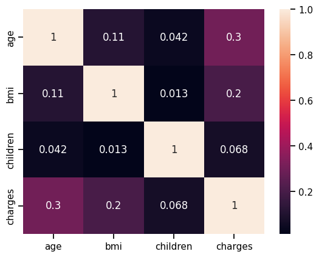

```python
sns.heatmap(df[df_numerical].corr(), annot = True) # visualizing the correlation
```

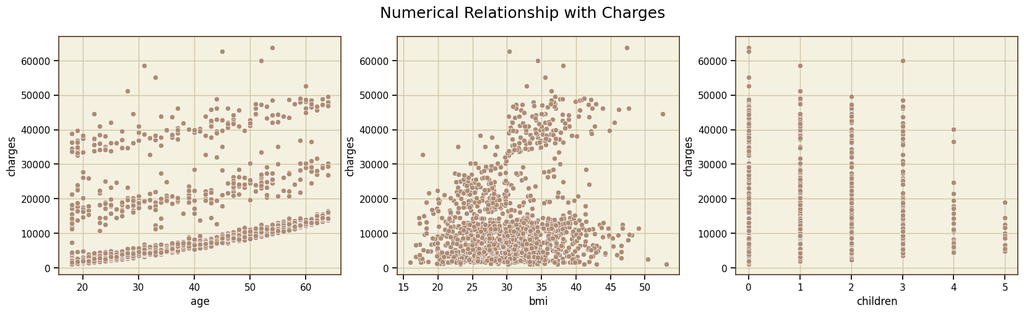

```python
fig, axs = plt.subplots(ncols = len(df_numerical)-1, figsize=(20, 5))
for i, col in enumerate([x for x in df_numerical if x != 'charges']):
    sns.scatterplot(df, x = col,y = df.charges, ax = axs[i])

plt.suptitle("Numerical Relationship with Charges", fontsize = 18)
```

#### Categorical Relationship

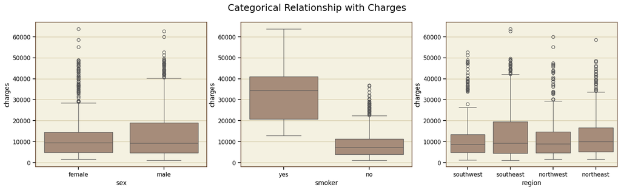

```python
fig, axs = plt.subplots(ncols = len(df_categorical), figsize=(20, 5))
for i, col in enumerate(df_categorical):
    sns.boxplot(df, x = col,y = df.charges, ax = axs[i])

plt.suptitle("Categorical Relationship with Charges", fontsize = 18)
```

```python
print("One way ANOVA test with Charges")
for i in df_categorical:
    f_stats = stats.f_oneway(*[df.loc[df[i] == x,"charges" ] for x in df[i].value_counts().index])
    print(i.title())
    print(f"F-Statistics: {f_stats.statistic:.8f}\t P-value: {f_stats.pvalue}")
```

```
One way ANOVA test with Charges
Sex
F-Statistics: 4.39970170	 P-value: 0.03613272100596256
Smoker
F-Statistics: 2177.61486806	 P-value: 8.271435842182967e-283
Region
F-Statistics: 2.96962669	 P-value: 0.0308933560705201
```

```python
# all are significant as p-value < 0.05 but smoker is really significant as it is approximately 0.00000
```

## Data Preprocessing

```python
from sklearn.preprocessing import OneHotEncoder, StandardScaler
```

#### One-Hot Encoding

One-Hot Encoding is needed as sklearn machine learning models cannot process text data but rather only works on numerical data

```python
encoder =  OneHotEncoder(sparse_output= False, drop = "first") # intialize one hot encoder without sparse format (CSR)

encoded = encoder.fit_transform(df[df_categorical]) # fit transform on categorical columns
df_encoded = pd.DataFrame(encoded, columns = encoder.get_feature_names_out())

df = pd.concat([df_encoded,df.drop(df_categorical, axis = 1)] , axis = 1) # drop categorical and concat with one hot encoded features
```

```python
df
```

|  | sex_male | smoker_yes | region_northwest | region_southeast | region_southwest | age | bmi | children | charges |
| --- | --- | --- | --- | --- | --- | --- | --- | --- | --- |
| 0 | 0.0 | 1.0 | 0.0 | 0.0 | 1.0 | 19 | 27.900 | 0 | 16884.92400 |
| 1 | 1.0 | 0.0 | 0.0 | 1.0 | 0.0 | 18 | 33.770 | 1 | 1725.55230 |
| 2 | 1.0 | 0.0 | 0.0 | 1.0 | 0.0 | 28 | 33.000 | 3 | 4449.46200 |
| 3 | 1.0 | 0.0 | 1.0 | 0.0 | 0.0 | 33 | 22.705 | 0 | 21984.47061 |
| 4 | 1.0 | 0.0 | 1.0 | 0.0 | 0.0 | 32 | 28.880 | 0 | 3866.85520 |
| ... | ... | ... | ... | ... | ... | ... | ... | ... | ... |
| 1333 | 1.0 | 0.0 | 1.0 | 0.0 | 0.0 | 50 | 30.970 | 3 | 10600.54830 |
| 1334 | 0.0 | 0.0 | 0.0 | 0.0 | 0.0 | 18 | 31.920 | 0 | 2205.98080 |
| 1335 | 0.0 | 0.0 | 0.0 | 1.0 | 0.0 | 18 | 36.850 | 0 | 1629.83350 |
| 1336 | 0.0 | 0.0 | 0.0 | 0.0 | 1.0 | 21 | 25.800 | 0 | 2007.94500 |
| 1337 | 0.0 | 1.0 | 1.0 | 0.0 | 0.0 | 61 | 29.070 | 0 | 29141.36030 |

1338 rows × 9 columns

#### Train Test Split

```python
from sklearn.model_selection import train_test_split

X = df.drop("charges", axis = 1)
y = df.charges

X_train, X_test, y_train, y_test = train_test_split(X, y, test_size= 0.2, random_state= 42)
```

#### Standard Scaling

```python
scaler = StandardScaler() # for regression model

X_train = pd.DataFrame(scaler.fit_transform(X_train), columns = scaler.get_feature_names_out()) # fit on train data and transform
X_test = pd.DataFrame(scaler.transform(X_test), columns = scaler.get_feature_names_out()) # transform train data
```

```python
X_train # scaled data
```

|  | sex_male | smoker_yes | region_northwest | region_southeast | region_southwest | age | bmi | children |
| --- | --- | --- | --- | --- | --- | --- | --- | --- |
| 0 | -1.024602 | -0.508747 | 1.783168 | -0.599661 | -0.572314 | 0.472227 | -1.756525 | 0.734336 |
| 1 | -1.024602 | -0.508747 | -0.560800 | -0.599661 | -0.572314 | 0.543313 | -1.033082 | -0.911192 |
| 2 | -1.024602 | -0.508747 | -0.560800 | 1.667609 | -0.572314 | 0.898745 | -0.943687 | -0.911192 |
| 3 | -1.024602 | -0.508747 | -0.560800 | 1.667609 | -0.572314 | -0.025379 | 0.622393 | 3.202629 |
| 4 | -1.024602 | -0.508747 | 1.783168 | -0.599661 | -0.572314 | 1.040918 | -1.504893 | 1.557100 |
| ... | ... | ... | ... | ... | ... | ... | ... | ... |
| 1065 | -1.024602 | -0.508747 | -0.560800 | -0.599661 | -0.572314 | -1.518194 | 0.130717 | 2.379865 |
| 1066 | -1.024602 | -0.508747 | -0.560800 | 1.667609 | -0.572314 | -0.025379 | -1.107579 | 3.202629 |
| 1067 | 0.975989 | -0.508747 | -0.560800 | -0.599661 | -0.572314 | 1.325264 | -0.891539 | -0.911192 |
| 1068 | -1.024602 | 1.965613 | -0.560800 | -0.599661 | 1.747292 | -0.167551 | 2.820864 | 0.734336 |
| 1069 | 0.975989 | -0.508747 | -0.560800 | -0.599661 | 1.747292 | 1.112004 | -0.109327 | -0.911192 |

1070 rows × 8 columns

#### Feature Importance

```python
from sklearn.tree import DecisionTreeRegressor

dtFeature = DecisionTreeRegressor(random_state=42)
dtFeature.fit(X_train, y_train)
```

```
DecisionTreeRegressor(random_state=42)
```

```python
importance = dtFeature.feature_importances_ # get data on feature importance
importance = pd.DataFrame(importance, index= dtFeature.feature_names_in_, columns = ["Importance"])
importance.sort_values(by = "Importance", ascending=False, inplace= True)
```

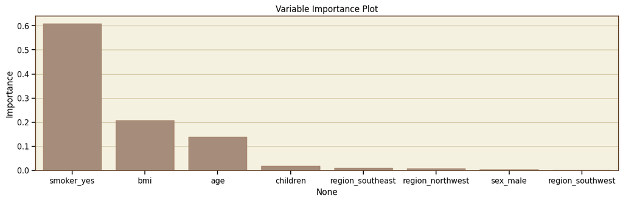

```python
plt.figure(figsize=(15, 4))
sns.barplot(importance, x = importance.index, y = "Importance")
plt.title("Variable Importance Plot")
```

```python
# region_southwest, northwest and sex_male is really unimportant compared to other features in the dataset
```

#### Feature Reduction

```python
X_train = X_train.drop(["region_northwest","sex_male","region_southwest"], axis = 1)
X_test = X_test.drop(["region_northwest","sex_male","region_southwest"], axis = 1)
```

## Model Development

```python
from sklearn.model_selection import GridSearchCV, KFold, cross_val_score
from sklearn.linear_model import LinearRegression
from sklearn.metrics import r2_score, root_mean_squared_error, mean_absolute_error, mean_squared_error
```

#### Linear Regression Model (base model)

```python
reg = LinearRegression()

# initial model
reg.fit(X_train, y_train)

# predict intially
y_initpred = reg.predict(X_test)

range_charges = df.charges.max() - df.charges.min() # for nRMSE
print("Linear Regression")
print(f"R-squared Score: {reg.score(X_test, y_test):.4f}\t(Explains approx. {reg.score(X_test, y_test)*100:.2f}% of variance in charges)\n") # score of model on test data
print(f"Mean Absolute Error\t:{mean_absolute_error(y_initpred, y_test):.4f}")
print(f"Mean Squared Error\t:{mean_squared_error(y_initpred, y_test):.4f}")
print(f"Root Mean Squared Error\t:{root_mean_squared_error(y_initpred, y_test):.4f}\n")
print(f"Normalized-Root Mean Squared Error:{root_mean_squared_error(y_initpred, y_test)/range_charges:.4f}")
```

```
Linear Regression
R-squared Score: 0.7822	(Explains approx. 78.22% of variance in charges)

Mean Absolute Error	:4200.4893
Mean Squared Error	:33820228.1391
Root Mean Squared Error	:5815.5162

Normalized-Root Mean Squared Error:0.0928
```

#### Decision Tree Regressor Model

```python
dt = DecisionTreeRegressor(random_state=42)
```

#### Hyperparameter Tuning + Cross Validation

```python
param_grid = {'max_depth': [10, 20, 30, None],
            'min_samples_split': [10, 15, 20],
            'min_samples_leaf': [4, 6, 8]}

kf = KFold(n_splits= 5, shuffle= True, random_state= 42)

gridsearch = GridSearchCV(dt, param_grid, cv=kf, scoring = "r2")
```

```python
gridsearch.fit(X_train, y_train)

gridsearch_results = pd.DataFrame(gridsearch.cv_results_) # store results of each hyperparameter and cross validation in a dataframe
```

```python
gridsearch_results.sort_values(by = "rank_test_score") # sort by rank to see which is the best parameter
```

|  | mean_fit_time | std_fit_time | mean_score_time | std_score_time | param_max_depth | param_min_samples_leaf | param_min_samples_split | params | split0_test_score | split1_test_score | split2_test_score | split3_test_score | split4_test_score | mean_test_score | std_test_score | rank_test_score |
| --- | --- | --- | --- | --- | --- | --- | --- | --- | --- | --- | --- | --- | --- | --- | --- | --- |
| 8 | 0.002638 | 0.000260 | 0.001349 | 0.000392 | 10 | 8 | 20 | {'max_depth': 10, 'min_samples_leaf': 8, 'min_... | 0.799075 | 0.825494 | 0.879763 | 0.814033 | 0.844950 | 0.832663 | 0.027914 | 1 |
| 17 | 0.002452 | 0.000102 | 0.001183 | 0.000059 | 20 | 8 | 20 | {'max_depth': 20, 'min_samples_leaf': 8, 'min_... | 0.799075 | 0.825618 | 0.879763 | 0.813394 | 0.844950 | 0.832560 | 0.027994 | 2 |
| 26 | 0.002449 | 0.000083 | 0.001154 | 0.000069 | 30 | 8 | 20 | {'max_depth': 30, 'min_samples_leaf': 8, 'min_... | 0.799075 | 0.825618 | 0.879763 | 0.813394 | 0.844950 | 0.832560 | 0.027994 | 2 |
| 35 | 0.002373 | 0.000045 | 0.001123 | 0.000060 | None | 8 | 20 | {'max_depth': None, 'min_samples_leaf': 8, 'mi... | 0.799075 | 0.825618 | 0.879763 | 0.813394 | 0.844950 | 0.832560 | 0.027994 | 2 |
| 7 | 0.002517 | 0.000073 | 0.001120 | 0.000049 | 10 | 8 | 15 | {'max_depth': 10, 'min_samples_leaf': 8, 'min_... | 0.799515 | 0.820046 | 0.878613 | 0.811647 | 0.845139 | 0.830992 | 0.028116 | 5 |
| 6 | 0.002868 | 0.000566 | 0.001245 | 0.000157 | 10 | 8 | 10 | {'max_depth': 10, 'min_samples_leaf': 8, 'min_... | 0.799515 | 0.820046 | 0.878613 | 0.811647 | 0.845139 | 0.830992 | 0.028116 | 5 |
| 16 | 0.002487 | 0.000082 | 0.001203 | 0.000126 | 20 | 8 | 15 | {'max_depth': 20, 'min_samples_leaf': 8, 'min_... | 0.799515 | 0.820154 | 0.878613 | 0.810418 | 0.845139 | 0.830768 | 0.028281 | 7 |
| 24 | 0.002431 | 0.000022 | 0.001177 | 0.000078 | 30 | 8 | 10 | {'max_depth': 30, 'min_samples_leaf': 8, 'min_... | 0.799515 | 0.820154 | 0.878613 | 0.810418 | 0.845139 | 0.830768 | 0.028281 | 7 |
| 25 | 0.002432 | 0.000051 | 0.001110 | 0.000047 | 30 | 8 | 15 | {'max_depth': 30, 'min_samples_leaf': 8, 'min_... | 0.799515 | 0.820154 | 0.878613 | 0.810418 | 0.845139 | 0.830768 | 0.028281 | 7 |
| 34 | 0.002435 | 0.000038 | 0.001095 | 0.000025 | None | 8 | 15 | {'max_depth': None, 'min_samples_leaf': 8, 'mi... | 0.799515 | 0.820154 | 0.878613 | 0.810418 | 0.845139 | 0.830768 | 0.028281 | 7 |
| 33 | 0.002418 | 0.000061 | 0.001535 | 0.000827 | None | 8 | 10 | {'max_depth': None, 'min_samples_leaf': 8, 'mi... | 0.799515 | 0.820154 | 0.878613 | 0.810418 | 0.845139 | 0.830768 | 0.028281 | 7 |
| 15 | 0.002511 | 0.000076 | 0.001289 | 0.000100 | 20 | 8 | 10 | {'max_depth': 20, 'min_samples_leaf': 8, 'min_... | 0.799515 | 0.820154 | 0.878613 | 0.810418 | 0.845139 | 0.830768 | 0.028281 | 7 |
| 5 | 0.002582 | 0.000205 | 0.001170 | 0.000080 | 10 | 6 | 20 | {'max_depth': 10, 'min_samples_leaf': 6, 'min_... | 0.796647 | 0.828848 | 0.869352 | 0.804267 | 0.832632 | 0.826349 | 0.025553 | 13 |
| 32 | 0.002447 | 0.000067 | 0.001083 | 0.000010 | None | 6 | 20 | {'max_depth': None, 'min_samples_leaf': 6, 'mi... | 0.795944 | 0.828680 | 0.869195 | 0.802351 | 0.832632 | 0.825760 | 0.025997 | 14 |
| 23 | 0.003197 | 0.001361 | 0.001146 | 0.000043 | 30 | 6 | 20 | {'max_depth': 30, 'min_samples_leaf': 6, 'min_... | 0.795944 | 0.828680 | 0.869195 | 0.802351 | 0.832632 | 0.825760 | 0.025997 | 14 |
| 14 | 0.002523 | 0.000095 | 0.001285 | 0.000084 | 20 | 6 | 20 | {'max_depth': 20, 'min_samples_leaf': 6, 'min_... | 0.795944 | 0.828680 | 0.869195 | 0.802351 | 0.832632 | 0.825760 | 0.025997 | 14 |
| 4 | 0.002705 | 0.000282 | 0.001267 | 0.000209 | 10 | 6 | 15 | {'max_depth': 10, 'min_samples_leaf': 6, 'min_... | 0.799721 | 0.827356 | 0.862918 | 0.800946 | 0.836066 | 0.825401 | 0.023591 | 17 |
| 31 | 0.003053 | 0.001016 | 0.001138 | 0.000046 | None | 6 | 15 | {'max_depth': None, 'min_samples_leaf': 6, 'mi... | 0.799018 | 0.827213 | 0.862798 | 0.798470 | 0.836512 | 0.824802 | 0.024269 | 18 |
| 22 | 0.002579 | 0.000078 | 0.001270 | 0.000100 | 30 | 6 | 15 | {'max_depth': 30, 'min_samples_leaf': 6, 'min_... | 0.799018 | 0.827213 | 0.862798 | 0.798470 | 0.836512 | 0.824802 | 0.024269 | 18 |
| 13 | 0.002542 | 0.000086 | 0.001294 | 0.000084 | 20 | 6 | 15 | {'max_depth': 20, 'min_samples_leaf': 6, 'min_... | 0.799018 | 0.827213 | 0.862798 | 0.798470 | 0.836512 | 0.824802 | 0.024269 | 18 |
| 2 | 0.002704 | 0.000144 | 0.001362 | 0.000226 | 10 | 4 | 20 | {'max_depth': 10, 'min_samples_leaf': 4, 'min_... | 0.787638 | 0.811850 | 0.871745 | 0.795040 | 0.838396 | 0.820934 | 0.030817 | 21 |
| 29 | 0.002545 | 0.000130 | 0.001126 | 0.000058 | None | 4 | 20 | {'max_depth': None, 'min_samples_leaf': 4, 'mi... | 0.788021 | 0.812870 | 0.871514 | 0.793048 | 0.838425 | 0.820776 | 0.030952 | 22 |
| 11 | 0.002571 | 0.000139 | 0.001190 | 0.000054 | 20 | 4 | 20 | {'max_depth': 20, 'min_samples_leaf': 4, 'min_... | 0.788021 | 0.812870 | 0.871514 | 0.793048 | 0.838425 | 0.820776 | 0.030952 | 22 |
| 20 | 0.002541 | 0.000097 | 0.001132 | 0.000048 | 30 | 4 | 20 | {'max_depth': 30, 'min_samples_leaf': 4, 'min_... | 0.788021 | 0.812870 | 0.871514 | 0.793048 | 0.838425 | 0.820776 | 0.030952 | 22 |
| 3 | 0.003406 | 0.000392 | 0.001760 | 0.000340 | 10 | 6 | 10 | {'max_depth': 10, 'min_samples_leaf': 6, 'min_... | 0.794047 | 0.818238 | 0.861515 | 0.796550 | 0.829300 | 0.819930 | 0.024644 | 25 |
| 12 | 0.002631 | 0.000067 | 0.001270 | 0.000130 | 20 | 6 | 10 | {'max_depth': 20, 'min_samples_leaf': 6, 'min_... | 0.793786 | 0.819471 | 0.861084 | 0.794073 | 0.829411 | 0.819565 | 0.025041 | 26 |
| 21 | 0.002572 | 0.000052 | 0.001176 | 0.000059 | 30 | 6 | 10 | {'max_depth': 30, 'min_samples_leaf': 6, 'min_... | 0.793786 | 0.819471 | 0.861084 | 0.794073 | 0.829411 | 0.819565 | 0.025041 | 26 |
| 30 | 0.002597 | 0.000125 | 0.001153 | 0.000065 | None | 6 | 10 | {'max_depth': None, 'min_samples_leaf': 6, 'mi... | 0.793786 | 0.819471 | 0.861084 | 0.794073 | 0.829411 | 0.819565 | 0.025041 | 26 |
| 28 | 0.002556 | 0.000065 | 0.001190 | 0.000058 | None | 4 | 15 | {'max_depth': None, 'min_samples_leaf': 4, 'mi... | 0.790339 | 0.808557 | 0.864027 | 0.785978 | 0.833339 | 0.816448 | 0.029057 | 29 |
| 19 | 0.002593 | 0.000073 | 0.001283 | 0.000154 | 30 | 4 | 15 | {'max_depth': 30, 'min_samples_leaf': 4, 'min_... | 0.790339 | 0.808557 | 0.864027 | 0.785978 | 0.833339 | 0.816448 | 0.029057 | 29 |
| 10 | 0.002617 | 0.000101 | 0.001184 | 0.000071 | 20 | 4 | 15 | {'max_depth': 20, 'min_samples_leaf': 4, 'min_... | 0.790339 | 0.808557 | 0.864027 | 0.785978 | 0.833339 | 0.816448 | 0.029057 | 29 |
| 1 | 0.002649 | 0.000109 | 0.001195 | 0.000074 | 10 | 4 | 15 | {'max_depth': 10, 'min_samples_leaf': 4, 'min_... | 0.790552 | 0.804562 | 0.864245 | 0.788552 | 0.833846 | 0.816351 | 0.028904 | 32 |
| 0 | 0.003180 | 0.000691 | 0.001326 | 0.000121 | 10 | 4 | 10 | {'max_depth': 10, 'min_samples_leaf': 4, 'min_... | 0.784055 | 0.789470 | 0.857869 | 0.792172 | 0.820543 | 0.808822 | 0.027597 | 33 |
| 27 | 0.002649 | 0.000058 | 0.001169 | 0.000082 | None | 4 | 10 | {'max_depth': None, 'min_samples_leaf': 4, 'mi... | 0.783537 | 0.795671 | 0.857787 | 0.787971 | 0.819067 | 0.808807 | 0.027385 | 34 |
| 9 | 0.002636 | 0.000058 | 0.001187 | 0.000082 | 20 | 4 | 10 | {'max_depth': 20, 'min_samples_leaf': 4, 'min_... | 0.783537 | 0.795671 | 0.857787 | 0.787971 | 0.819067 | 0.808807 | 0.027385 | 34 |
| 18 | 0.002624 | 0.000048 | 0.001187 | 0.000096 | 30 | 4 | 10 | {'max_depth': 30, 'min_samples_leaf': 4, 'min_... | 0.783537 | 0.795671 | 0.857787 | 0.787971 | 0.819067 | 0.808807 | 0.027385 | 34 |

We can see that the max depth does not matter whether if it is {30/20/None} when the min leaf and min split is 8 and 20 respectively  
The splits and best hyperparameters yielded an average R-squared score of 0.833 on the decision tree model  
The small difference in scores between each splits proves the model generalizability on different sets of unseen data

```python
y_pred = gridsearch.best_estimator_.predict(X_test) # trying model with the best parameter and generalizability on the test data
print("Decision Tree")
print(f"Best Parameters: {gridsearch.best_params_}\nR-squared Score: {gridsearch.best_estimator_.score(X_test, y_test):.4f}\t(Explains approx. {gridsearch.best_estimator_.score(X_test, y_test)*100:.2f}% of variance in charges)\n")
print(f"Mean Absolute Error\t:{mean_absolute_error(y_pred, y_test):.4f}")
print(f"Mean Squared Error\t:{mean_squared_error(y_pred, y_test):.4f}")
print(f"Root Mean Squared Error\t:{root_mean_squared_error(y_pred, y_test):.4f}")
print(f"Normalized-Root Mean Squared Error:{root_mean_squared_error(y_pred, y_test)/range_charges:.4f}")
```

```
Decision Tree
Best Parameters: {'max_depth': 10, 'min_samples_leaf': 8, 'min_samples_split': 20}
R-squared Score: 0.8588	(Explains approx. 85.88% of variance in charges)

Mean Absolute Error	:2710.9581
Mean Squared Error	:21919463.2299
Root Mean Squared Error	:4681.8226
Normalized-Root Mean Squared Error:0.0747
```

```python
# Conclusion, Decision Tree model with its best hyperparameters perform relatively better than Linear Regression Model
```

```python
# Use Decision Tree Model on unseen data and predict the charges
```

### Dump Model

```python
import joblib
joblib.dump(gridsearch.best_estimator_, 'medical_cost.joblib')
```

```
['medical_cost.joblib']
```